# Manage Nodes

[[edit on GitHub]](https://github.com/chef/chef-web-docs/blob/main/content/server_manage_nodes.md)

[figure not shown]

Warning

Chef Manage is deprecated and no longer under active development. It is supported on Chef Automate installations up to version 1.8 and replaced by Chef Automate 2.0. Contact your Chef account representative for information about upgrading your system. See our Automate documentation to learn more about Chef Automate 2.

This document is no longer maintained.

Note

This topic is about using the Chef management console to manage nodes.

A node is any device—physical, virtual, cloud, network device, etc.—that is under management by Chef Infra.

## Manage

Nodes can be managed from the Chef management console web user interface.

### Delete

To delete a node:

1. Open the Chef management console.
2. Click **Nodes**.
3. Select a node.
4. Click **Delete**.
5. Confirm:

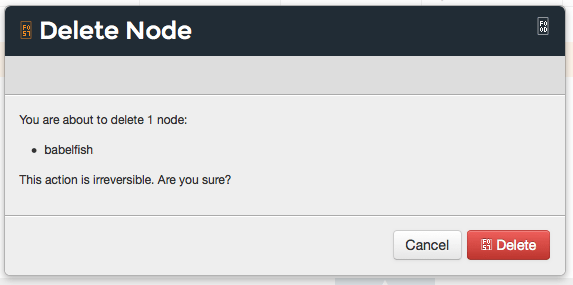

### Reset Key

To reset the validation key for a node:

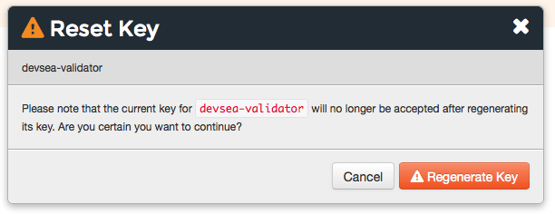

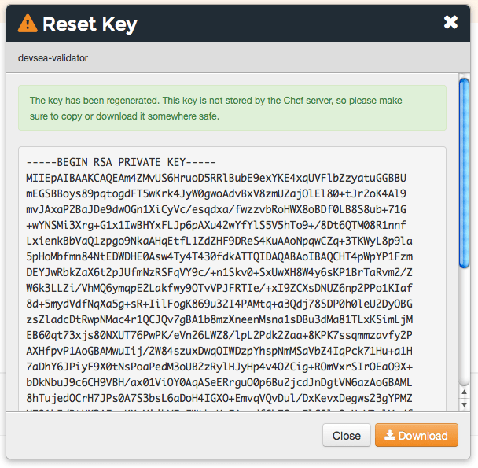

### Search

To search nodes:

1. Open the Chef management console.
2. Click **Nodes**.
3. In the search box in the upper right, enter the search query and click the search icon.
4. The results will appear in the list below.

## Node Attributes

An attribute is a specific detail about a node. Attributes are used by Chef Infra Client to understand:

- The current state of the node
- What the state of the node was at the end of the previous Chef Infra Client run
- What the state of the node should be at the end of the current Chef Infra Client run

Attributes are defined by:

- The node as saved on the Chef Infra Server
- Attributes passed via JSON on the command line
- Cookbooks (in attribute files and/or recipes)
- Policyfiles

During every Chef Infra Client run, Chef Infra Client builds the attribute list using:

- Attributes passed via JSON on the command line
- Data about the node collected by Ohai.
- The node object that was saved to the Chef Infra Server at the end of the previous Chef Infra Client run.
- The rebuilt node object from the current Chef Infra Client run, after it is updated for changes to cookbooks (attribute files and/or recipes) and/or Policyfiles, and updated for any changes to the state of the node itself.

After the node object is rebuilt, all of the attributes are compared, and then the node is updated based on attribute precedence. At the end of every Chef Infra Client run, the node object that defines the current state of the node is uploaded to the Chef Infra Server so that it can be indexed for search.

### Edit Attribute

To edit node attributes:

1. Open the Chef management console.
2. Click **Nodes**.
3. Select a node.
4. Click the **Attributes** tab.
5. Click **Edit**.
6. In the **Edit Node Attributes** dialog box, make your changes:

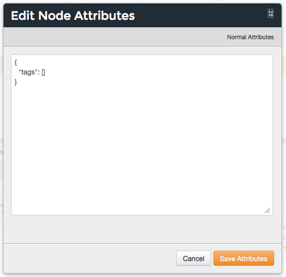

7. Click **Save Attributes**.

### View Attributes

To view the attributes for a node:

1. Open the Chef management console.
2. Click **Nodes**.
3. Select a node.
4. Click the **Attributes** tab.
5. Click **Edit**.

## Run-lists

A run-list defines all of the information necessary for Chef to configure a node into the desired state. A run-list is:

- An ordered list of roles and/or recipes that are run in the exact order defined in the run-list; if a recipe appears more than once in the run-list, Chef Infra Client will not run it twice
- Always specific to the node on which it runs; nodes may have a run-list that is identical to the run-list used by other nodes
- Stored as part of the node object on the Chef server
- Maintained using knife and then uploaded from the workstation to the Chef Infra Server, or maintained using Chef Automate

### Add Recipe to

To add a role or recipe to a run-list:

1. Open the Chef management console.
2. Click **Nodes**.
3. Select a node.
4. Click **Edit Run List**.
5. In the **Edit Node Run List** dialog box, drag the role or recipe from the **Available Roles** or **Available Recipes** lists to the current run-list.

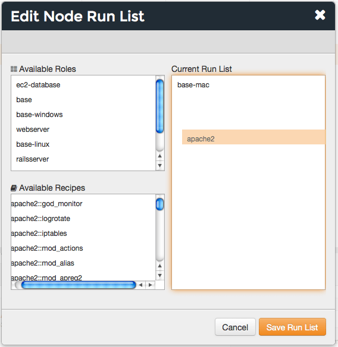

6. Click **Save Run List**.

### Add Role to

To add a role or recipe to a run-list:

1. Open the Chef management console.
2. Click **Nodes**.
3. Select a node.
4. Click **Edit Run List**.
5. In the **Edit Node Run List** dialog box, drag the role or recipe from the **Available Roles** or **Available Recipes** lists to the current run-list.

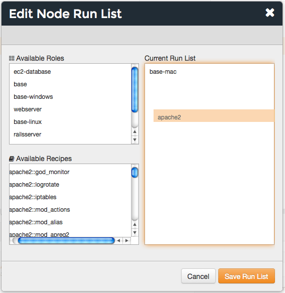

6. Click **Save Run List**.

### Edit

To edit a run-list:

1. Open the Chef management console.
2. Click **Nodes**.
3. Select a node.
4. Click **Edit Run List**.
5. In the **Edit Node Run List** dialog box, make your changes.
6. Click **Save Run List**.

### Remove Recipe from

To remove a role or recipe from a run-list:

1. Open the Chef management console.
2. Click **Nodes**.
3. Select a node.
4. Click **Edit Run List**.
5. In the **Edit Node Run List** dialog box, drag the role or recipe from the **Current Run List** to the list of available roles or recipes.

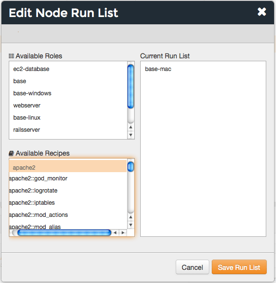

6. Click **Save Run List**.

### Remove Role from

To remove a role or recipe from a run-list:

1. Open the Chef management console.
2. Click **Nodes**.
3. Select a node.
4. Click **Edit Run List**.
5. In the **Edit Node Run List** dialog box, drag the role or recipe from the **Current Run List** to the list of available roles or recipes.

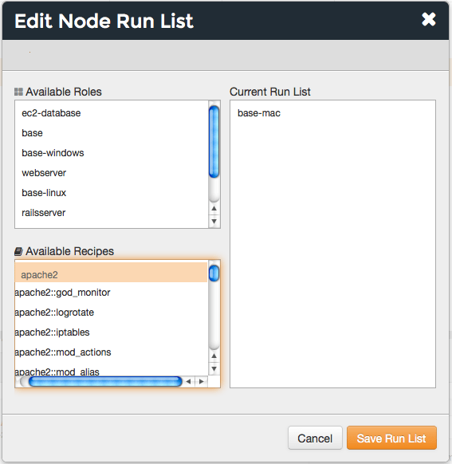

6. Click **Save Run List**.

### View Current

To view the current run-list for a node:

1. Open the Chef management console.
2. Click **Nodes**.
3. Select a node.
4. Click the **Details** tab.
5. The current run-list is shown in the lower right:

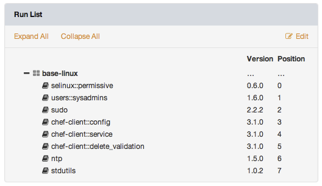

## Permissions

Permissions are used in the Chef Infra Server to define how users and groups can interact with objects on the server. Permissions are configured per-organization.

The Chef Infra Server includes the following object permissions:

[output not shown]

### Set

To set permissions list for a node object:

1. Open the Chef management console.
2. Click **Nodes**.
3. Select a node.
4. Click the **Permissions** tab.
5. For each group listed under **Name**, select or de-select the **Read**, **Update**, **Delete**, and **Grant** permissions.

### Update

To update the permissions list for a node object:

1. Open the Chef management console.
2. Click **Nodes**.
3. Select a node.
4. Click the **Permissions** tab.
5. Click the **+ Add** button and enter the name of the user or group to be added.
6. Select or de-select **Read**, **Update**, **Delete**, and **Grant** to update the permissions list for the user or group.

### View

To view permissions for a node:

1. Open the Chef management console.
2. Click **Nodes**.
3. Select a node.
4. Click the **Permissions** tab.
5. Set the appropriate permissions: **Delete**, **Grant**, **Read**, and/or **Update**.

## Manage Tags

A tag is a custom description that is applied to a node. A tag, once applied, can be helpful when managing nodes using knife or when building recipes by providing alternate methods of grouping similar types of information.

### Add

To add tags to a node (or a group of nodes):

1. Open the Chef management console.
2. Click **Nodes**.
3. Select a node (or a group of nodes).
4. Click **Manage Tags**.
5. In the **Manage Node Tags** dialog box, enter the name of the tag and then select **Add Tags** from the drop-down.

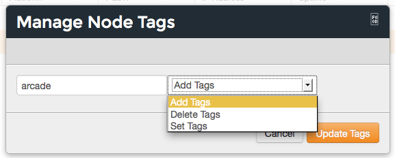

6. Click **Update Tags**.

### Delete

To delete tags for a node (or a group of nodes):

1. Open the Chef management console.
2. Click **Nodes**.
3. Select a node (or a group of nodes).
4. Click **Manage Tags**.
5. In the **Manage Node Tags** dialog box, enter the name of the tag and then select **Delete Tags** from the drop-down.

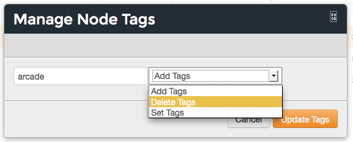

6. Click **Update Tags**.

### View

To view all of the nodes:

1. Open the Chef management console.
2. Click **Nodes**.
3. Select a node.
4. Select the **Details** tab.
5. The tags for the node appear under the **Tags** header:

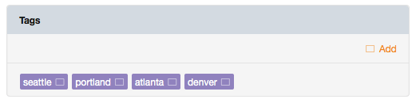